# R Mini Bootcamp: Beginner-level Focus

Jake Leighton - G&E Data Science Working Group

February 5th, 2026

© Jake Leighton, MD Anderson Cancer Center  
Adapted from DPLM Computational Training Program  
Shared for educational use as part of this workshop

# 1 Welcome to R Programming!

This document contains all the code and exercises for our introductory R Programming Workshop. This workshop is designed for complete beginners with no prior programming experience.

## 1.1 Learning Objectives

By the end of this workshop, you will be able to:

**Part 1: R Fundamentals and Data Structures**

- Navigate the RStudio interface
- Install R packages and load libraries
- Understand basic data types in R
- Create and manipulate vectors
- Work with data frames
- Access built-in datasets

**Part 2: Data Import and Manipulation**

- Import and export data files
- Handle missing data appropriately
- Manipulate data frames using base R
- Use tidyverse/dplyr for elegant data manipulation
- Chain operations using the pipe operator

# 2 PART 1: R Fundamentals and Data Structures

# 3 Getting Started with RStudio

## 3.1 The RStudio Interface

RStudio has four main panes:

1. **Script Editor** (top-left): Write and save your code
2. **Console** (bottom-left): Run commands interactively
3. **Environment/History** (top-right): See your variables
4. **Files/Plots/Packages/Help** (bottom-right): Navigate files and view outputs

## 3.2 Your First R Commands

```r
# This is a comment - R ignores anything after #
print("Hello, TMP!")
```

```
## [1] "Hello, TMP!"
```

```r
# R can be used as a calculator
2 + 2
```

```
## [1] 4
```

```r
10 * 5
```

```
## [1] 50
```

```r
100 / 4
```

```
## [1] 25
```

## 3.3 What are R Packages?

**Packages** = Collections of functions, data, and documentation that extend R’s capabilities  
**Library** = The folder where packages are stored on your computer

Think of packages as toolboxes with specialized tools for specific tasks.

## 3.4 Installing Packages

```r
# Install a single package from CRAN
install.packages("ggplot2")

# Install multiple packages
install.packages(c("tidyverse", "dplyr", "tidyr", "readr", "lubridate", "patchwork"))

# Install from GitHub (requires devtools)
install.packages("devtools")
devtools::install_github("username/packagename")

# Install from Bioconductor
if (!require("BiocManager", quietly = TRUE))
    install.packages("BiocManager")

BiocManager::install("ComplexHeatmap")
```

**Note:** You only install once, but must load packages each R session.

## 3.5 Loading Packages

```r
# Load a package for use
library(ggplot2)

# Alternative method
require(dplyr)
```

## 3.6 Essential Package Commands

```r
# Check if package is installed
"ggplot2" %in% rownames(installed.packages())

# List loaded packages
(.packages())

# Update all packages
update.packages(ask = FALSE)

# Get help on a package
help(package = "ggplot2")

# Remove a package
remove.packages("packagename")
```

## 3.7 Common Issues & Solutions

| Issue | Solution |
| --- | --- |
| “Package not found” after installation | Load it with `library()` first |
| “Not available for this version of R” | Update R or find compatible package version |
| Permission errors | Run RStudio as administrator (Windows) or set personal library |
| Package version not found in CRAN | Install from Bioconductor or GitHub |

## 3.8 Getting Help

```r
# Get help on a function
?mean
# help(mean)  # Alternative way

# Search for help topics
# help.search("average")
```

# 4 Basic Data Types

## 4.1 Numeric, Character, and Logical

```r
# Numeric
my_number <- 42
my_decimal <- 3.14

# Character (text)
my_name <- "R Programmer"
my_sentence <- 'I love R!'  # Single or double quotes work

# Logical (TRUE/FALSE)
is_fun <- TRUE
is_difficult <- FALSE

# Check the type of a variable
class(my_number)
```

```
## [1] "numeric"
```

```r
class(my_name)
```

```
## [1] "character"
```

```r
class(is_fun)
```

```
## [1] "logical"
```

## 4.2 Variables and Assignment

```r
# Use <- for assignment (preferred in R)
x <- 10
y <- 20

# You can also use = but <- is conventional
z = 30

# Perform operations with variables
result <- x + y + z
result
```

```
## [1] 60
```

```r
# Variable names should be descriptive
student_age <- 22
student_name <- "Alice"
```

# 5 Working with Vectors

## 5.1 Creating Vectors

```r
# Use c() to combine elements into a vector
numbers <- c(1, 2, 3, 4, 5)
numbers
```

```
## [1] 1 2 3 4 5
```

```r
# Create sequences
seq_1_to_10 <- 1:10
seq_1_to_10
```

```
##  [1]  1  2  3  4  5  6  7  8  9 10
```

```r
# More complex sequences
even_numbers <- seq(from = 2, to = 20, by = 2)
even_numbers
```

```
##  [1]  2  4  6  8 10 12 14 16 18 20
```

```r
# Repeating values
repeated <- rep(100, times = 5)
repeated
```

```
## [1] 100 100 100 100 100
```

```r
# Character vectors
fruits <- c("apple", "banana", "orange", "grape")
fruits
```

```
## [1] "apple"  "banana" "orange" "grape"
```

```r
# Logical vectors
test_scores <- c(TRUE, TRUE, FALSE, TRUE)
test_scores
```

```
## [1]  TRUE  TRUE FALSE  TRUE
```

## 5.2 Vector Operations

```r
# Arithmetic operations apply to all elements
numbers <- c(1, 2, 3, 4, 5)
numbers * 2
```

```
## [1]  2  4  6  8 10
```

```r
numbers + 10
```

```
## [1] 11 12 13 14 15
```

```r
numbers^2
```

```
## [1]  1  4  9 16 25
```

```r
# Operations between vectors
vec1 <- c(1, 2, 3)
vec2 <- c(10, 20, 30)
vec1 + vec2
```

```
## [1] 11 22 33
```

```r
vec1 * vec2
```

```
## [1] 10 40 90
```

```r
# Vector recycling (R repeats shorter vector)
long_vec <- 1:10
short_vec <- c(1, 2)
long_vec + short_vec  # short_vec is recycled
```

```
##  [1]  2  4  4  6  6  8  8 10 10 12
```

## 5.3 Indexing and Subsetting Vectors

```r
fruits <- c("apple", "banana", "orange", "grape", "kiwi")

# Access single element (R uses 1-based indexing)
fruits[1]  # First element
```

```
## [1] "apple"
```

```r
fruits[3]  # Third element
```

```
## [1] "orange"
```

```r
# Access multiple elements
fruits[c(1, 3, 5)]
```

```
## [1] "apple"  "orange" "kiwi"
```

```r
fruits[2:4]
```

```
## [1] "banana" "orange" "grape"
```

```r
# Negative indexing (exclude elements)
fruits[-1]  # All except first
```

```
## [1] "banana" "orange" "grape"  "kiwi"
```

```r
fruits[-c(2, 4)]  # All except 2nd and 4th
```

```
## [1] "apple"  "orange" "kiwi"
```

```r
# Logical indexing
numbers <- c(10, 25, 30, 45, 50)
numbers > 30
```

```
## [1] FALSE FALSE FALSE  TRUE  TRUE
```

```r
numbers[numbers > 30]  # Get elements greater than 30
```

```
## [1] 45 50
```

## 5.4 Vector Functions

```r
numbers <- c(15, 28, 31, 42, 56, 67, 73, 89, 91, 100)

# Basic statistics
length(numbers)
```

```
## [1] 10
```

```r
sum(numbers)
```

```
## [1] 592
```

```r
mean(numbers)
```

```
## [1] 59.2
```

```r
median(numbers)
```

```
## [1] 61.5
```

```r
min(numbers)
```

```
## [1] 15
```

```r
max(numbers)
```

```
## [1] 100
```

```r
range(numbers)
```

```
## [1]  15 100
```

```r
# Other useful functions
sort(numbers)
```

```
##  [1]  15  28  31  42  56  67  73  89  91 100
```

```r
rev(numbers)
```

```
##  [1] 100  91  89  73  67  56  42  31  28  15
```

```r
unique(c(1, 2, 2, 3, 3, 3, 4))
```

```
## [1] 1 2 3 4
```

# 6 Data Structures

## 6.1 Lists

```r
# Lists can contain different types
my_list <- list(
  name = "John",
  age = 30,
  scores = c(85, 90, 78),
  passed = TRUE
)
my_list
```

```
## $name
## [1] "John"
##
## $age
## [1] 30
##
## $scores
## [1] 85 90 78
##
## $passed
## [1] TRUE
```

```r
# Access list elements
my_list$name
```

```
## [1] "John"
```

```r
my_list[[1]]  # By position
```

```
## [1] "John"
```

```r
my_list[["age"]]  # By name
```

```
## [1] 30
```

```r
# Lists can contain other lists
nested_list <- list(
  student1 = list(name = "Alice", grade = 85),
  student2 = list(name = "Bob", grade = 92)
)
nested_list
```

```
## $student1
## $student1$name
## [1] "Alice"
##
## $student1$grade
## [1] 85
##
##
## $student2
## $student2$name
## [1] "Bob"
##
## $student2$grade
## [1] 92
```

## 6.2 Matrices

```r
# Create a matrix
matrix1 <- matrix(1:12, nrow = 3, ncol = 4)
matrix1
```

```
##      [,1] [,2] [,3] [,4]
## [1,]    1    4    7   10
## [2,]    2    5    8   11
## [3,]    3    6    9   12
```

```r
# Create by binding vector rows
row1 <- c(1, 2, 3)
row2 <- c(4, 5, 6)
row3 <- c(7, 8, 9)
matrix2 <- rbind(row1, row2, row3)
matrix2
```

```
##      [,1] [,2] [,3]
## row1    1    2    3
## row2    4    5    6
## row3    7    8    9
```

```r
# Create by binding vector columns
col1 <- c(1, 2, 3)
col2 <- c(4, 5, 6)
col3 <- c(7, 8, 9)
matrix3 <- cbind(col1, col2, col3)
matrix3
```

```
##      col1 col2 col3
## [1,]    1    4    7
## [2,]    2    5    8
## [3,]    3    6    9
```

```r
# Access elements
matrix3[1, 2]  # Row 1, Column 2
```

```
## col2
##    4
```

```r
matrix3[2, ]   # All of row 2
```

```
## col1 col2 col3
##    2    5    8
```

```r
matrix3[, 3]   # All of column 3
```

```
## [1] 7 8 9
```

## 6.3 Data Frames - The Most Important Structure!

Data frames are the workhorse of R data analysis. They are similar to spreadsheets or tables, with rows representing observations and columns representing variables.

```r
# Create a data frame from vectors
student_names <- c("Alice", "Bob", "Charlie", "Diana")
ages <- c(21, 22, 20, 23)
grades <- c(85, 92, 78, 95)
passed <- c(TRUE, TRUE, FALSE, TRUE)

students <- data.frame(
  name = student_names,
  age = ages,
  grade = grades,
  passed = passed
)
students
```

```
##      name age grade passed
## 1   Alice  21    85   TRUE
## 2     Bob  22    92   TRUE
## 3 Charlie  20    78  FALSE
## 4   Diana  23    95   TRUE
```

```r
# Alternatively use cbind and colnames
students_v2 <- as.data.frame(cbind(student_names, ages, grades, passed))
colnames(students_v2) <- c("name", "age", "grade", "passed")
students_v2
```

```
##      name age grade passed
## 1   Alice  21    85   TRUE
## 2     Bob  22    92   TRUE
## 3 Charlie  20    78  FALSE
## 4   Diana  23    95   TRUE
```

```r
# Check structure
str(students)
```

```
## 'data.frame':    4 obs. of  4 variables:
##  $ name  : chr  "Alice" "Bob" "Charlie" "Diana"
##  $ age   : num  21 22 20 23
##  $ grade : num  85 92 78 95
##  $ passed: logi  TRUE TRUE FALSE TRUE
```

```r
str(students_v2)
```

```
## 'data.frame':    4 obs. of  4 variables:
##  $ name  : chr  "Alice" "Bob" "Charlie" "Diana"
##  $ age   : chr  "21" "22" "20" "23"
##  $ grade : chr  "85" "92" "78" "95"
##  $ passed: chr  "TRUE" "TRUE" "FALSE" "TRUE"
```

## 6.4 Working with Data Frames

```r
# View first/last rows
head(students, 2)
```

```
##    name age grade passed
## 1 Alice  21    85   TRUE
## 2   Bob  22    92   TRUE
```

```r
tail(students, 2)
```

```
##      name age grade passed
## 3 Charlie  20    78  FALSE
## 4   Diana  23    95   TRUE
```

```r
# Get dimensions
nrow(students)
```

```
## [1] 4
```

```r
ncol(students)
```

```
## [1] 4
```

```r
dim(students)
```

```
## [1] 4 4
```

```r
# Access columns
students$name
```

```
## [1] "Alice"   "Bob"     "Charlie" "Diana"
```

```r
students[["grade"]]
```

```
## [1] 85 92 78 95
```

```r
students[, "age"]
```

```
## [1] 21 22 20 23
```

```r
students[, 2]  # Second column
```

```
## [1] 21 22 20 23
```

```r
# Access rows
students[1, ]  # First row
```

```
##    name age grade passed
## 1 Alice  21    85   TRUE
```

```r
students[2:3, ]  # Rows 2 and 3
```

```
##      name age grade passed
## 2     Bob  22    92   TRUE
## 3 Charlie  20    78  FALSE
```

```r
# Access specific cells
students[1, 3]  # Row 1, Column 3
```

```
## [1] 85
```

```r
students[2, "grade"]  # Row 2, grade column
```

```
## [1] 92
```

```r
# Add new column
students$letter_grade <- c("B", "A", "C", "A")
students
```

```
##      name age grade passed letter_grade
## 1   Alice  21    85   TRUE            B
## 2     Bob  22    92   TRUE            A
## 3 Charlie  20    78  FALSE            C
## 4   Diana  23    95   TRUE            A
```

```r
# Merging data frames
name <- c("Bob", "Alice", "Charlie")
year <- c("Senior", "Junior", "Sophomore")
students_year <- as.data.frame(cbind(name, year))
students_year
```

```
##      name      year
## 1     Bob    Senior
## 2   Alice    Junior
## 3 Charlie Sophomore
```

```r
students_years <- merge(students, students_year)
students_years
```

```
##      name age grade passed letter_grade      year
## 1   Alice  21    85   TRUE            B    Junior
## 2     Bob  22    92   TRUE            A    Senior
## 3 Charlie  20    78  FALSE            C Sophomore
```

```r
# Summary statistics
summary(students_years)
```

```
##      name                age           grade        passed
##  Length:3           Min.   :20.0   Min.   :78.0   Mode :logical
##  Class :character   1st Qu.:20.5   1st Qu.:81.5   FALSE:1
##  Mode  :character   Median :21.0   Median :85.0   TRUE :2
##                     Mean   :21.0   Mean   :85.0
##                     3rd Qu.:21.5   3rd Qu.:88.5
##                     Max.   :22.0   Max.   :92.0
##  letter_grade           year
##  Length:3           Length:3
##  Class :character   Class :character
##  Mode  :character   Mode  :character
##
##
##
```

# 7 Working with Built-in Datasets

```r
# R comes with many datasets for practice
# Let's explore options from the built-in {datasets} package
data()  # See available datasets

# Load and explore mtcars
data(mtcars)
head(mtcars)
```

```
##                    mpg cyl disp  hp drat    wt  qsec vs am gear carb
## Mazda RX4         21.0   6  160 110 3.90 2.620 16.46  0  1    4    4
## Mazda RX4 Wag     21.0   6  160 110 3.90 2.875 17.02  0  1    4    4
## Datsun 710        22.8   4  108  93 3.85 2.320 18.61  1  1    4    1
## Hornet 4 Drive    21.4   6  258 110 3.08 3.215 19.44  1  0    3    1
## Hornet Sportabout 18.7   8  360 175 3.15 3.440 17.02  0  0    3    2
## Valiant           18.1   6  225 105 2.76 3.460 20.22  1  0    3    1
```

```r
# Basic exploration
str(mtcars)
```

```
## 'data.frame':    32 obs. of  11 variables:
##  $ mpg : num  21 21 22.8 21.4 18.7 18.1 14.3 24.4 22.8 19.2 ...
##  $ cyl : num  6 6 4 6 8 6 8 4 4 6 ...
##  $ disp: num  160 160 108 258 360 ...
##  $ hp  : num  110 110 93 110 175 105 245 62 95 123 ...
##  $ drat: num  3.9 3.9 3.85 3.08 3.15 2.76 3.21 3.69 3.92 3.92 ...
##  $ wt  : num  2.62 2.88 2.32 3.21 3.44 ...
##  $ qsec: num  16.5 17 18.6 19.4 17 ...
##  $ vs  : num  0 0 1 1 0 1 0 1 1 1 ...
##  $ am  : num  1 1 1 0 0 0 0 0 0 0 ...
##  $ gear: num  4 4 4 3 3 3 3 4 4 4 ...
##  $ carb: num  4 4 1 1 2 1 4 2 2 4 ...
```

```r
summary(mtcars)
```

```
##       mpg             cyl             disp             hp
##  Min.   :10.40   Min.   :4.000   Min.   : 71.1   Min.   : 52.0
##  1st Qu.:15.43   1st Qu.:4.000   1st Qu.:120.8   1st Qu.: 96.5
##  Median :19.20   Median :6.000   Median :196.3   Median :123.0
##  Mean   :20.09   Mean   :6.188   Mean   :230.7   Mean   :146.7
##  3rd Qu.:22.80   3rd Qu.:8.000   3rd Qu.:326.0   3rd Qu.:180.0
##  Max.   :33.90   Max.   :8.000   Max.   :472.0   Max.   :335.0
##       drat             wt             qsec             vs
##  Min.   :2.760   Min.   :1.513   Min.   :14.50   Min.   :0.0000
##  1st Qu.:3.080   1st Qu.:2.581   1st Qu.:16.89   1st Qu.:0.0000
##  Median :3.695   Median :3.325   Median :17.71   Median :0.0000
##  Mean   :3.597   Mean   :3.217   Mean   :17.85   Mean   :0.4375
##  3rd Qu.:3.920   3rd Qu.:3.610   3rd Qu.:18.90   3rd Qu.:1.0000
##  Max.   :4.930   Max.   :5.424   Max.   :22.90   Max.   :1.0000
##        am              gear            carb
##  Min.   :0.0000   Min.   :3.000   Min.   :1.000
##  1st Qu.:0.0000   1st Qu.:3.000   1st Qu.:2.000
##  Median :0.0000   Median :4.000   Median :2.000
##  Mean   :0.4062   Mean   :3.688   Mean   :2.812
##  3rd Qu.:1.0000   3rd Qu.:4.000   3rd Qu.:4.000
##  Max.   :1.0000   Max.   :5.000   Max.   :8.000
```

```r
colnames(mtcars)
```

```
##  [1] "mpg"  "cyl"  "disp" "hp"   "drat" "wt"   "qsec" "vs"   "am"   "gear"
## [11] "carb"
```

```r
# Try another dataset
data(iris)
head(iris)
```

```
##   Sepal.Length Sepal.Width Petal.Length Petal.Width Species
## 1          5.1         3.5          1.4         0.2  setosa
## 2          4.9         3.0          1.4         0.2  setosa
## 3          4.7         3.2          1.3         0.2  setosa
## 4          4.6         3.1          1.5         0.2  setosa
## 5          5.0         3.6          1.4         0.2  setosa
## 6          5.4         3.9          1.7         0.4  setosa
```

```r
dim(iris)
```

```
## [1] 150   5
```

# 8 Saving Code/Workspace and Exiting Session

```r
# Open/Save R code as .R file
# File -> New File -> R Script
# File -> Save As -> my_code.R
# source("my_code.R")

# Save the workspace to a .RData file
# Environment -> save icon
save.image(file = "my_workspace.RData")
# load("~/my_workspace.RData")

# Exiting RStudio Session
rm(list=ls())
dev.off()
# RStudio -> Quit RStudio
# Don't Save workspace image to .RData!!
```

# 9 Practice Exercises: Part 1

## 9.1 Exercise 1: Vector Manipulation

```r
# Create a vector of temperatures in Celsius
temps_c <- c(...)

# 1. Convert to Fahrenheit (F = C * 9/5 + 32)

# 2. Find temperatures above 20°C

# 3. Calculate the mean temperature

# 4. Find the hottest and coldest days
```

## 9.2 Exercise 1: Solution

```r
# Create a vector of temperatures in Celsius
temps_c <- c(20, 25, 18, 30, 22, 27, 15)

# 1. Convert to Fahrenheit
temps_f <- temps_c * 9/5 + 32
temps_f
```

```
## [1] 68.0 77.0 64.4 86.0 71.6 80.6 59.0
```

```r
# 2. Find temperatures above 20°C
warm_days <- temps_c[temps_c > 20]
warm_days
```

```
## [1] 25 30 22 27
```

```r
# 3. Calculate the mean temperature
avg_temp <- mean(temps_c)
avg_temp
```

```
## [1] 22.42857
```

```r
# 4. Find the hottest and coldest days
hottest <- max(temps_c)
coldest <- min(temps_c)
c(hottest = hottest, coldest = coldest)
```

```
## hottest coldest
##      30      15
```

## 9.3 Exercise 2: Create Your Own Data Frame

```r
# Create a data frame about books with:
# - title (at least 4 books)
# - author
# - pages
# - fiction (TRUE/FALSE)

books <- data.frame(...
)

# 1. Display the structure of your data frame

# 2. Find books with more than 300 pages

# 3. Calculate the average number of pages

# 4. Show only fiction books
```

## 9.4 Exercise 2: Solution

```r
# Create a data frame about books
books <- data.frame(
  title = c("1984", "Pride and Prejudice", "Sapiens", "The Hobbit"),
  author = c("Orwell", "Austen", "Harari", "Tolkien"),
  pages = c(328, 432, 443, 310),
  fiction = c(TRUE, TRUE, FALSE, TRUE)
)

# 1. Display the structure
str(books)
```

```
## 'data.frame':    4 obs. of  4 variables:
##  $ title  : chr  "1984" "Pride and Prejudice" "Sapiens" "The Hobbit"
##  $ author : chr  "Orwell" "Austen" "Harari" "Tolkien"
##  $ pages  : num  328 432 443 310
##  $ fiction: logi  TRUE TRUE FALSE TRUE
```

```r
# 2. Find books with more than 300 pages
long_books <- books[books$pages > 300, ]
long_books
```

```
##                 title  author pages fiction
## 1                1984  Orwell   328    TRUE
## 2 Pride and Prejudice  Austen   432    TRUE
## 3             Sapiens  Harari   443   FALSE
## 4          The Hobbit Tolkien   310    TRUE
```

```r
# 3. Calculate the average number of pages
mean(books$pages)
```

```
## [1] 378.25
```

```r
# 4. Show only fiction books
fiction_books <- books[books$fiction == TRUE, ]
fiction_books
```

```
##                 title  author pages fiction
## 1                1984  Orwell   328    TRUE
## 2 Pride and Prejudice  Austen   432    TRUE
## 4          The Hobbit Tolkien   310    TRUE
```

## 9.5 Exercise 3: Exploring iris Dataset

```r
# Using the iris dataset
data(iris)

# 1. What are the column names?

# 2. How many observations are there?

# 3. What is the mean Sepal.Length?

# 4. Select only the setosa species

# 5. Find flowers with Petal.Length > 4
```

## 9.6 Exercise 3: Solution

```r
# Using the iris dataset
data(iris)

# 1. Column names
colnames(iris)
```

```
## [1] "Sepal.Length" "Sepal.Width"  "Petal.Length" "Petal.Width"  "Species"
```

```r
# 2. Number of observations
nrow(iris)
```

```
## [1] 150
```

```r
# 3. Mean Sepal.Length
mean(iris$Sepal.Length)
```

```
## [1] 5.843333
```

```r
# 4. Select only setosa species
setosa_only <- iris[iris$Species == "setosa", ]
head(setosa_only)
```

```
##   Sepal.Length Sepal.Width Petal.Length Petal.Width Species
## 1          5.1         3.5          1.4         0.2  setosa
## 2          4.9         3.0          1.4         0.2  setosa
## 3          4.7         3.2          1.3         0.2  setosa
## 4          4.6         3.1          1.5         0.2  setosa
## 5          5.0         3.6          1.4         0.2  setosa
## 6          5.4         3.9          1.7         0.4  setosa
```

```r
# 5. Flowers with Petal.Length > 4
large_petals <- iris[iris$Petal.Length > 4, ]
head(large_petals)
```

```
##    Sepal.Length Sepal.Width Petal.Length Petal.Width    Species
## 51          7.0         3.2          4.7         1.4 versicolor
## 52          6.4         3.2          4.5         1.5 versicolor
## 53          6.9         3.1          4.9         1.5 versicolor
## 55          6.5         2.8          4.6         1.5 versicolor
## 56          5.7         2.8          4.5         1.3 versicolor
## 57          6.3         3.3          4.7         1.6 versicolor
```

# 10 PART 2: Data Import and Manipulation

Now that you understand R’s fundamental data types and structures, we’ll learn how to import data from external files and manipulate it using both base R and the powerful tidyverse package.

## 10.1 Load Required Packages

```r
# Load packages
library(tidyverse)  # Includes dplyr, ggplot2, and more
library(patchwork)  # Combine multiple tidyverse objects
```

# 11 Working with Files and Directories

## 11.1 Understanding Working Directories

```r
# Check your current working directory
getwd()

# Set working directory (adjust path as needed)
setwd("~/Desktop/R_bootcamp")  # Mac/Linux
# setwd("C:/Users/YourName/Documents/R_Workshop")  # Windows

# List files in current directory
list.files()

# Better practice: use relative paths or RStudio projects
```

# 12 Load Workshop Datasets: ChickWeight and DNase

For the rest of this workshop, we’ll work with two built-in R datasets that are great for learning data manipulation:

**ChickWeight**: A study tracking chick weights over time under different diets - `weight`: Body weight of the chick (grams) - `Time`: Number of days since birth - `Chick`: Unique chick identifier - `Diet`: Experimental diet (1, 2, 3, or 4)

This study asks the question: Does diet affect chicken growth rate?

- Compares chicken growth trajectories across the 4 diet groups.

**DNase**: An enzyme assay measuring optical density at various concentrations - `Run`: Assay run identifier - `conc`: Protein concentration - `density`: Optical density reading

This is data from an ELISA-style assay for DNase I enzyme activity, where the experiment:

- Prepared wells with known concentrations of DNase I protein
- Ran the assay and measured the optical density (which reflects how much enzymatic reaction occurred).
- Each ‘Run’ (1–11) is a complete replicate of the entire standard curve experiment.

```r
# Load and preview our datasets
data(ChickWeight)
data(DNase)

# Take a first look at ChickWeight
head(ChickWeight)
```

```
##   weight Time Chick Diet
## 1     42    0     1    1
## 2     51    2     1    1
## 3     59    4     1    1
## 4     64    6     1    1
## 5     76    8     1    1
## 6     93   10     1    1
```

```r
str(ChickWeight)
```

```
## Classes 'nfnGroupedData', 'nfGroupedData', 'groupedData' and 'data.frame':   578 obs. of  4 variables:
##  $ weight: num  42 51 59 64 76 93 106 125 149 171 ...
##  $ Time  : num  0 2 4 6 8 10 12 14 16 18 ...
##  $ Chick : Ord.factor w/ 50 levels "18"<"16"<"15"<..: 15 15 15 15 15 15 15 15 15 15 ...
##  $ Diet  : Factor w/ 4 levels "1","2","3","4": 1 1 1 1 1 1 1 1 1 1 ...
##  - attr(*, "formula")=Class 'formula'  language weight ~ Time | Chick
##   .. ..- attr(*, ".Environment")=<environment: R_EmptyEnv>
##  - attr(*, "outer")=Class 'formula'  language ~Diet
##   .. ..- attr(*, ".Environment")=<environment: R_EmptyEnv>
##  - attr(*, "labels")=List of 2
##   ..$ x: chr "Time"
##   ..$ y: chr "Body weight"
##  - attr(*, "units")=List of 2
##   ..$ x: chr "(days)"
##   ..$ y: chr "(gm)"
```

```r
summary(ChickWeight)
```

```
##      weight           Time           Chick     Diet
##  Min.   : 35.0   Min.   : 0.00   13     : 12   1:220
##  1st Qu.: 63.0   1st Qu.: 4.00   9      : 12   2:120
##  Median :103.0   Median :10.00   20     : 12   3:120
##  Mean   :121.8   Mean   :10.72   10     : 12   4:118
##  3rd Qu.:163.8   3rd Qu.:16.00   17     : 12
##  Max.   :373.0   Max.   :21.00   19     : 12
##                                  (Other):506
```

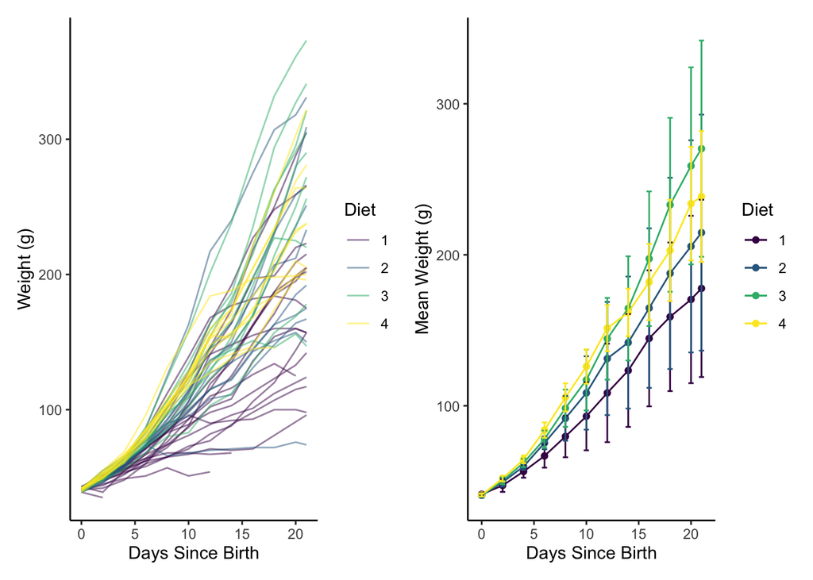

```r
# Plot overview of ChickWeight growth curves
p1 <- ggplot(ChickWeight, aes(x = Time, y = weight, group = Chick, color = Diet)) +
  geom_line(alpha = 0.5) +
  scale_colour_viridis_d() +
  labs(x = "Days Since Birth", y = "Weight (g)") +
  theme_classic()

# Group diets together
ChickWeight_avg <- ChickWeight %>%
  group_by(Diet, Time) %>%
  summarize(
    mean_weight = mean(weight),
    sd_weight = sd(weight)
  )

# Plot growth curves per diet
p2 <- ggplot(ChickWeight_avg, aes(x = Time, y = mean_weight, color = Diet)) +
  geom_point() +
  geom_line() +
  scale_colour_viridis_d() +
  geom_errorbar(aes(ymin = mean_weight - sd_weight,
                    ymax = mean_weight + sd_weight), width = 0.5) +
  labs(x = "Days Since Birth", y = "Mean Weight (g)") +
  theme_classic()

p1 + p2
```

```r
# Take a first look at DNase
head(DNase)
```

```
##   Run       conc density
## 1   1 0.04882812   0.017
## 2   1 0.04882812   0.018
## 3   1 0.19531250   0.121
## 4   1 0.19531250   0.124
## 5   1 0.39062500   0.206
## 6   1 0.39062500   0.215
```

```r
str(DNase)
```

```
## Classes 'nfnGroupedData', 'nfGroupedData', 'groupedData' and 'data.frame':   176 obs. of  3 variables:
##  $ Run    : Ord.factor w/ 11 levels "10"<"11"<"9"<..: 4 4 4 4 4 4 4 4 4 4 ...
##  $ conc   : num  0.0488 0.0488 0.1953 0.1953 0.3906 ...
##  $ density: num  0.017 0.018 0.121 0.124 0.206 0.215 0.377 0.374 0.614 0.609 ...
##  - attr(*, "formula")=Class 'formula'  language density ~ conc | Run
##   .. ..- attr(*, ".Environment")=<environment: R_EmptyEnv>
##  - attr(*, "labels")=List of 2
##   ..$ x: chr "DNase concentration"
##   ..$ y: chr "Optical density"
##  - attr(*, "units")=List of 1
##   ..$ x: chr "(ng/ml)"
```

```r
summary(DNase)
```

```
##       Run          conc             density
##  10     :16   Min.   : 0.04883   Min.   :0.0110
##  11     :16   1st Qu.: 0.34180   1st Qu.:0.1978
##  9      :16   Median : 1.17188   Median :0.5265
##  1      :16   Mean   : 3.10669   Mean   :0.7192
##  4      :16   3rd Qu.: 3.90625   3rd Qu.:1.1705
##  8      :16   Max.   :12.50000   Max.   :2.0030
##  (Other):80
```

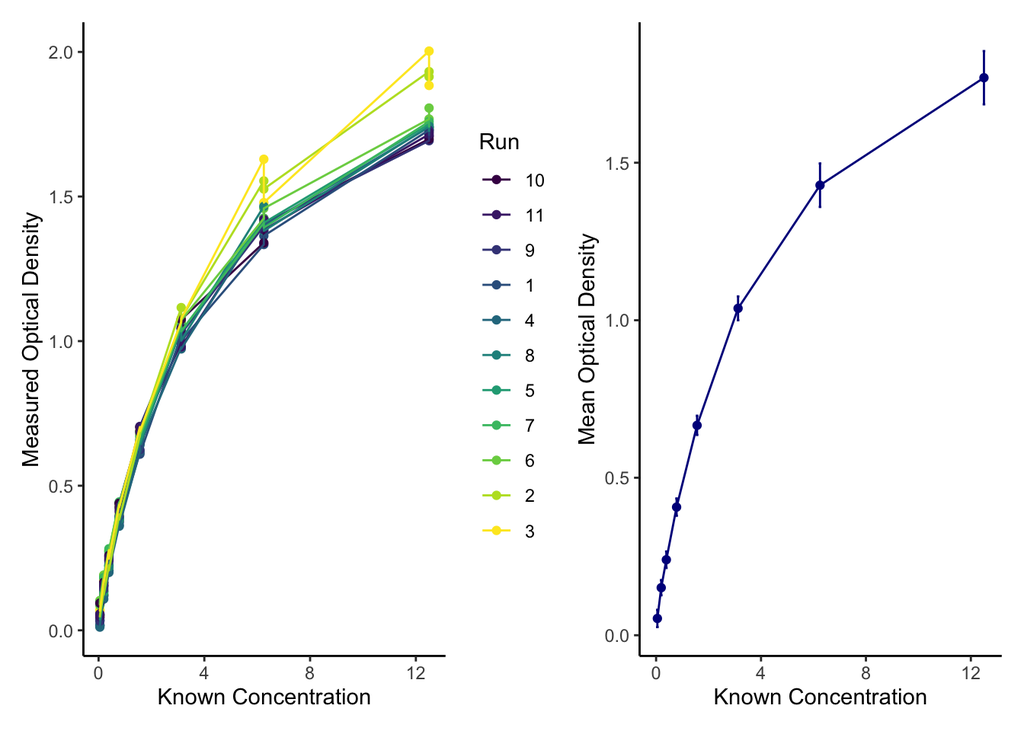

```r
# Plot overview of DNase I enzyme activity
p3 <- ggplot(DNase, aes(x = conc, y = density, color = Run)) +
  geom_point() +
  geom_line() +
  scale_colour_viridis_d() +
  labs(x = "Known Concentration", y = "Measured Optical Density") +
  theme_classic()

# Combine all replicate runs for standard curve
DNase_avg <- DNase %>%
  group_by(conc) %>%
  summarize(
    mean_density = mean(density),
    sd_density = sd(density)
  )

# Plot standard curve
p4 <- ggplot(DNase_avg, aes(x = conc, y = mean_density)) +
  geom_point(color = "darkblue") +
  geom_line(color = "darkblue") +
  geom_errorbar(aes(ymin = mean_density - sd_density,
                    ymax = mean_density + sd_density),
                    width = 0.1, color = "darkblue") +
  labs(x = "Known Concentration", y = "Mean Optical Density") +
  theme_classic()

p3 + p4
```

# 13 Exporting Data

## 13.1 Saving CSV Files

Let’s save our datasets as files to practice import/export:

```r
# Save ChickWeight to CSV
write.csv(ChickWeight, "chick_weight.csv", row.names = FALSE)

# Write without quotes around strings
write.csv(ChickWeight, "chick_weight_quotes.csv",
          row.names = FALSE, quote = FALSE)

# Use readr for better CSV writing
write_csv(ChickWeight, "chick_weight_readr.csv")

# Save DNase to CSV
write.csv(DNase, "dnase_assay.csv", row.names = FALSE)

# Create a messy version of DNase with issues for cleaning practice
messy_DNase <- data.frame(
  DENSITY = c("  0.017  ", "0.018", "0.121", "ERROR", "0.124"),
  conc = c(0.04882812, 0.04882812, 0.19531250, 0.19531250, 0.39062500),
  Run = c("Run 1", "run 1", "RUN 1", NA, "Run_1")
)

# Save messy_DNase to CSV
write.csv(messy_DNase, "messy_DNase.csv", row.names = FALSE)
```

# 14 Importing Data

## 14.1 Reading CSV Files

```r
# Basic CSV reading
chicks1 <- read.csv("chick_weight.csv")
head(chicks1)
```

```
##   weight Time Chick Diet
## 1     42    0     1    1
## 2     51    2     1    1
## 3     59    4     1    1
## 4     64    6     1    1
## 5     76    8     1    1
## 6     93   10     1    1
```

```r
# With additional parameters
chicks2 <- read.csv("chick_weight.csv",
                  stringsAsFactors = FALSE,  # Keep strings as characters
                  na.strings = c("NA", "N/A", ""))  # Define NA values
str(chicks2)
```

```
## 'data.frame':    578 obs. of  4 variables:
##  $ weight: int  42 51 59 64 76 93 106 125 149 171 ...
##  $ Time  : int  0 2 4 6 8 10 12 14 16 18 ...
##  $ Chick : int  1 1 1 1 1 1 1 1 1 1 ...
##  $ Diet  : int  1 1 1 1 1 1 1 1 1 1 ...
```

```r
# Using readr (tidyverse) - often better!
chicks3 <- read_csv("chick_weight.csv")  # Note: read_csv not read.csv
glimpse(chicks3)  # tidyverse way to view structure
```

```
## Rows: 578
## Columns: 4
## $ weight <dbl> 42, 51, 59, 64, 76, 93, 106, 125, 149, 171, 199, 205, 40, 49, 5…
## $ Time   <dbl> 0, 2, 4, 6, 8, 10, 12, 14, 16, 18, 20, 21, 0, 2, 4, 6, 8, 10, 1…
## $ Chick  <dbl> 1, 1, 1, 1, 1, 1, 1, 1, 1, 1, 1, 1, 2, 2, 2, 2, 2, 2, 2, 2, 2, …
## $ Diet   <dbl> 1, 1, 1, 1, 1, 1, 1, 1, 1, 1, 1, 1, 1, 1, 1, 1, 1, 1, 1, 1, 1, …
```

# 15 Managing Different Delimiters

```r
# Create tab-delimited file
write.table(ChickWeight, "chick_weight.txt", sep = "\t", row.names = FALSE)

# Read tab-delimited
tab_data <- read.table("chick_weight.txt", header = TRUE, sep = "\t")
head(tab_data)
```

```
##   weight Time Chick Diet
## 1     42    0     1    1
## 2     51    2     1    1
## 3     59    4     1    1
## 4     64    6     1    1
## 5     76    8     1    1
## 6     93   10     1    1
```

```r
# For other delimiters (semicolon, pipe, etc.)
# read.table("file.txt", sep = ";")  # Semicolon
# read.table("file.txt", sep = "|")  # Pipe
```

# 16 Handling Missing Data

Missing data is extremely common in real-world datasets. Learning to identify and handle `NA` values is essential.

```r
# Create a version of ChickWeight with some missing values for practice
chicks_with_na <- ChickWeight
chicks_with_na$weight[c(5, 15, 25, 50)] <- NA  # Introduce some NAs
write.csv(chicks_with_na, "chicks_with_na.csv", row.names = FALSE)

# Read and check for missing values
df_with_na <- read.csv("chicks_with_na.csv")
summary(df_with_na)
```

```
##      weight           Time           Chick            Diet
##  Min.   : 35.0   Min.   : 0.00   Min.   : 1.00   Min.   :1.000
##  1st Qu.: 63.0   1st Qu.: 4.00   1st Qu.:13.00   1st Qu.:1.000
##  Median :103.0   Median :10.00   Median :26.00   Median :2.000
##  Mean   :122.3   Mean   :10.72   Mean   :25.75   Mean   :2.235
##  3rd Qu.:164.0   3rd Qu.:16.00   3rd Qu.:38.00   3rd Qu.:3.000
##  Max.   :373.0   Max.   :21.00   Max.   :50.00   Max.   :4.000
##  NA's   :4
```

```r
# Count NAs per column
colSums(is.na(df_with_na))
```

```
## weight   Time  Chick   Diet
##      4      0      0      0
```

```r
# Find rows with any NA
rows_with_na <- df_with_na[!complete.cases(df_with_na), ]
rows_with_na
```

```
##    weight Time Chick Diet
## 5      NA    8     1    1
## 15     NA    4     2    1
## 25     NA    0     3    1
## 50     NA    2     5    1
```

```r
# Remove rows with NA
df_no_na <- na.omit(df_with_na)
nrow(df_no_na)
```

```
## [1] 574
```

```r
# Replace NA with specific value (e.g., mean weight)
df_filled <- df_with_na
df_filled$weight[is.na(df_filled$weight)] <- mean(df_filled$weight, na.rm = TRUE)
head(df_filled, 30)
```

```
##      weight Time Chick Diet
## 1   42.0000    0     1    1
## 2   51.0000    2     1    1
## 3   59.0000    4     1    1
## 4   64.0000    6     1    1
## 5  122.2857    8     1    1
## 6   93.0000   10     1    1
## 7  106.0000   12     1    1
## 8  125.0000   14     1    1
## 9  149.0000   16     1    1
## 10 171.0000   18     1    1
## 11 199.0000   20     1    1
## 12 205.0000   21     1    1
## 13  40.0000    0     2    1
## 14  49.0000    2     2    1
```

[output cut: 16 more lines]

# 17 Base R Data Manipulation

## 17.1 Subsetting and Filtering

```r
# Work with ChickWeight
df <- as.data.frame(ChickWeight)

# Select columns
df_subset1 <- df[, c("weight", "Time", "Diet")]
head(df_subset1)
```

```
##   weight Time Diet
## 1     42    0    1
## 2     51    2    1
## 3     59    4    1
## 4     64    6    1
## 5     76    8    1
## 6     93   10    1
```

```r
# Select columns by number
df_subset2 <- df[, c(1, 2, 4)]
head(df_subset2)
```

```
##   weight Time Diet
## 1     42    0    1
## 2     51    2    1
## 3     59    4    1
## 4     64    6    1
## 5     76    8    1
## 6     93   10    1
```

```r
# Filter rows - chicks heavier than 100 grams
heavy_chicks <- df[df$weight > 100, ]
head(heavy_chicks)
```

```
##    weight Time Chick Diet
## 7     106   12     1    1
## 8     125   14     1    1
## 9     149   16     1    1
## 10    171   18     1    1
## 11    199   20     1    1
## 12    205   21     1    1
```

```r
# Complex conditions - Diet 1 chicks heavier than 100g
diet1_heavy <- df[df$Diet == 1 & df$weight > 100, ]
head(diet1_heavy)
```

```
##    weight Time Chick Diet
## 7     106   12     1    1
## 8     125   14     1    1
## 9     149   16     1    1
## 10    171   18     1    1
## 11    199   20     1    1
## 12    205   21     1    1
```

```r
# Using subset() function
subset_result <- subset(df, Time > 10 & Diet %in% c(1, 2))
head(subset_result)
```

```
##    weight Time Chick Diet
## 7     106   12     1    1
## 8     125   14     1    1
## 9     149   16     1    1
## 10    171   18     1    1
## 11    199   20     1    1
## 12    205   21     1    1
```

## 17.2 Adding and Modifying Columns

```r
# Add new column - weight in kilograms
df$weight_kg <- df$weight / 1000
head(df)
```

```
##   weight Time Chick Diet weight_kg
## 1     42    0     1    1     0.042
## 2     51    2     1    1     0.051
## 3     59    4     1    1     0.059
## 4     64    6     1    1     0.064
## 5     76    8     1    1     0.076
## 6     93   10     1    1     0.093
```

```r
# Conditional new column - weight category
df$weight_category <- ifelse(df$weight >= 150, "Heavy",
                        ifelse(df$weight >= 100, "Medium", "Light"))
head(df)
```

```
##   weight Time Chick Diet weight_kg weight_category
## 1     42    0     1    1     0.042           Light
## 2     51    2     1    1     0.051           Light
## 3     59    4     1    1     0.059           Light
## 4     64    6     1    1     0.064           Light
## 5     76    8     1    1     0.076           Light
## 6     93   10     1    1     0.093           Light
```

```r
# Modify existing column - create age groups
df$age_group <- cut(df$Time,
                    breaks = c(-1, 7, 14, 21),
                    labels = c("Week1", "Week2", "Week3"))
head(df)
```

```
##   weight Time Chick Diet weight_kg weight_category age_group
## 1     42    0     1    1     0.042           Light     Week1
## 2     51    2     1    1     0.051           Light     Week1
## 3     59    4     1    1     0.059           Light     Week1
## 4     64    6     1    1     0.064           Light     Week1
## 5     76    8     1    1     0.076           Light     Week2
## 6     93   10     1    1     0.093           Light     Week2
```

```r
# Remove columns
df_reduced <- df[, !names(df) %in% c("weight_kg", "weight_category")]
head(df_reduced)
```

```
##   weight Time Chick Diet age_group
## 1     42    0     1    1     Week1
## 2     51    2     1    1     Week1
## 3     59    4     1    1     Week1
## 4     64    6     1    1     Week1
## 5     76    8     1    1     Week2
## 6     93   10     1    1     Week2
```

# 18 Introduction to Tidyverse/dplyr

The tidyverse is a collection of R packages designed for data science. The dplyr package within tidyverse provides a grammar of data manipulation that makes your code more readable and easier to write.

## 18.1 The Pipe Operator %>%

The pipe operator `%>%` is one of the most powerful features of tidyverse. It takes the output from one function and passes it as the first argument to the next function, allowing you to chain operations together.

```r
# Traditional nested approach (hard to read)
result1 <- head(sort(ChickWeight$weight), 3)
result1
```

```
## [1] 35 39 39
```

```r
# With pipe (read left to right)
result2 <- ChickWeight$weight %>%
  sort() %>%
  head(3)
result2
```

```
## [1] 35 39 39
```

```r
# Multiple operations
ChickWeight %>%
  nrow()  # Count rows
```

```
## [1] 578
```

```r
ChickWeight %>%
  summary()  # Get summary
```

```
##      weight           Time           Chick     Diet
##  Min.   : 35.0   Min.   : 0.00   13     : 12   1:220
##  1st Qu.: 63.0   1st Qu.: 4.00   9      : 12   2:120
##  Median :103.0   Median :10.00   20     : 12   3:120
##  Mean   :121.8   Mean   :10.72   10     : 12   4:118
##  3rd Qu.:163.8   3rd Qu.:16.00   17     : 12
##  Max.   :373.0   Max.   :21.00   19     : 12
##                                  (Other):506
```

## 18.2 Core dplyr Verbs

The dplyr package has five main “verbs” (functions) that cover most data manipulation needs:

- `select()` - Choose columns
- `filter()` - Choose rows
- `mutate()` - Create/modify columns
- `arrange()` - Sort data
- `summarize()` - Compute summaries

### 18.2.1 select() - Choose Columns

```r
# Select specific columns
ChickWeight %>%
  select(weight, Time, Diet) %>%
  head()
```

```
##   weight Time Diet
## 1     42    0    1
## 2     51    2    1
## 3     59    4    1
## 4     64    6    1
## 5     76    8    1
## 6     93   10    1
```

```r
# Select columns by pattern
ChickWeight %>%
  select(starts_with("w")) %>%  # Columns starting with 'w'
  head()
```

```
##   weight
## 1     42
## 2     51
## 3     59
## 4     64
## 5     76
## 6     93
```

```r
# Select all except certain columns
ChickWeight %>%
  select(-Chick) %>%
  head()
```

```
##   weight Time Diet
## 1     42    0    1
## 2     51    2    1
## 3     59    4    1
## 4     64    6    1
## 5     76    8    1
## 6     93   10    1
```

```r
# Reorder columns
ChickWeight %>%
  select(Diet, Chick, Time, everything()) %>%
  head()
```

```
##   Diet Chick Time weight
## 1    1     1    0     42
## 2    1     1    2     51
## 3    1     1    4     59
## 4    1     1    6     64
## 5    1     1    8     76
## 6    1     1   10     93
```

### 18.2.2 filter() - Choose Rows

```r
# Simple filter - chicks heavier than 200g
ChickWeight %>%
  filter(weight > 200)
```

```
##    weight Time Chick Diet
## 1     205   21     1    1
## 2     209   20     2    1
## 3     215   21     2    1
## 4     202   21     3    1
## 5     220   20     5    1
## 6     223   21     5    1
## 7     218   16     7    1
## 8     250   18     7    1
## 9     288   20     7    1
## 10    305   21     7    1
## 11    205   21    12    1
## 12    227   16    14    1
## 13    248   18    14    1
## 14    259   20    14    1
```

[output cut: 70 more lines]

```r
# Multiple conditions (AND)
ChickWeight %>%
  filter(weight > 200, Diet == 1)
```

```
##    weight Time Chick Diet
## 1     205   21     1    1
## 2     209   20     2    1
## 3     215   21     2    1
## 4     202   21     3    1
## 5     220   20     5    1
## 6     223   21     5    1
## 7     218   16     7    1
## 8     250   18     7    1
## 9     288   20     7    1
## 10    305   21     7    1
## 11    205   21    12    1
## 12    227   16    14    1
## 13    248   18    14    1
## 14    259   20    14    1
## 15    266   21    14    1
```

```r
# OR conditions
ChickWeight %>%
  filter(Time == 0 | Time == 21)
```

```
##    weight Time Chick Diet
## 1      42    0     1    1
## 2     205   21     1    1
## 3      40    0     2    1
## 4     215   21     2    1
## 5      43    0     3    1
## 6     202   21     3    1
## 7      42    0     4    1
## 8     157   21     4    1
## 9      41    0     5    1
## 10    223   21     5    1
## 11     41    0     6    1
## 12    157   21     6    1
## 13     41    0     7    1
## 14    305   21     7    1
```

[output cut: 81 more lines]

```r
# Using %in%
ChickWeight %>%
  filter(Diet %in% c(1, 2)) %>%
  head()
```

```
##   weight Time Chick Diet
## 1     42    0     1    1
## 2     51    2     1    1
## 3     59    4     1    1
## 4     64    6     1    1
## 5     76    8     1    1
## 6     93   10     1    1
```

```r
# Let's look at DNase - filter for high density readings
DNase %>%
  filter(density > 1.5)
```

```
##    Run  conc density
## 1    1 12.50   1.730
## 2    1 12.50   1.710
## 3    2  6.25   1.554
## 4    2  6.25   1.526
## 5    2 12.50   1.932
## 6    2 12.50   1.914
## 7    3  6.25   1.629
## 8    3 12.50   2.003
## 9    3 12.50   1.884
## 10   4 12.50   1.740
## 11   4 12.50   1.732
## 12   5 12.50   1.750
## 13   5 12.50   1.738
## 14   6 12.50   1.768
## 15   6 12.50   1.806
## 16   7 12.50   1.759
## 17   7 12.50   1.739
## 18   8 12.50   1.743
## 19   8 12.50   1.724
## 20   9 12.50   1.693
## 21   9 12.50   1.729
## 22  10 12.50   1.699
## 23  10 12.50   1.708
## 24  11 12.50   1.715
## 25  11 12.50   1.721
```

### 18.2.3 mutate() - Create/Modify Columns

```r
# Add single column - weight in kg
ChickWeight %>%
  mutate(weight_kg = weight / 1000) %>%
  head()
```

```
##   weight Time Chick Diet weight_kg
## 1     42    0     1    1     0.042
## 2     51    2     1    1     0.051
## 3     59    4     1    1     0.059
## 4     64    6     1    1     0.064
## 5     76    8     1    1     0.076
## 6     93   10     1    1     0.093
```

```r
# Add multiple columns
ChickWeight %>%
  mutate(
    weight_kg = weight / 1000,
    is_heavy = weight > 150,
    time_weeks = Time / 7
  ) %>%
  head()
```

```
##   weight Time Chick Diet weight_kg is_heavy time_weeks
## 1     42    0     1    1     0.042    FALSE  0.0000000
## 2     51    2     1    1     0.051    FALSE  0.2857143
## 3     59    4     1    1     0.059    FALSE  0.5714286
## 4     64    6     1    1     0.064    FALSE  0.8571429
## 5     76    8     1    1     0.076    FALSE  1.1428571
## 6     93   10     1    1     0.093    FALSE  1.4285714
```

```r
# Modify existing column
ChickWeight %>%
  mutate(Time = Time + 1) %>%  # Shift time by 1
  head()
```

```
##   weight Time Chick Diet
## 1     42    1     1    1
## 2     51    3     1    1
## 3     59    5     1    1
## 4     64    7     1    1
## 5     76    9     1    1
## 6     93   11     1    1
```

```r
# Use case_when for complex conditions
ChickWeight %>%
  mutate(
    weight_class = case_when(
      weight >= 200 ~ "Large",
      weight >= 100 ~ "Medium",
      weight >= 50 ~ "Small",
      TRUE ~ "Very Small"  # Default case
    )
  ) %>%
  head()
```

```
##   weight Time Chick Diet weight_class
## 1     42    0     1    1   Very Small
## 2     51    2     1    1        Small
## 3     59    4     1    1        Small
## 4     64    6     1    1        Small
## 5     76    8     1    1        Small
## 6     93   10     1    1        Small
```

### 18.2.4 arrange() - Sort Data

```r
# Sort by one column
ChickWeight %>%
  arrange(weight) %>%
  head()
```

```
##   weight Time Chick Diet
## 1     35    2    18    1
## 2     39    2     3    1
## 3     39    0    18    1
## 4     39    0    27    2
## 5     39    0    28    2
## 6     39    0    29    2
```

```r
# Sort descending
ChickWeight %>%
  arrange(desc(weight)) %>%
  head()
```

```
##   weight Time Chick Diet
## 1    373   21    35    3
## 2    361   20    35    3
## 3    341   21    34    3
## 4    332   18    35    3
## 5    331   21    21    2
## 6    327   20    34    3
```

```r
# Sort by multiple columns
ChickWeight %>%
  arrange(Diet, desc(weight)) %>%
  head()
```

```
##   weight Time Chick Diet
## 1    305   21     7    1
## 2    288   20     7    1
## 3    266   21    14    1
## 4    259   20    14    1
## 5    250   18     7    1
## 6    248   18    14    1
```

### 18.2.5 summarize() - Compute Summaries

```r
# Single summary
ChickWeight %>%
  summarize(mean_weight = mean(weight))
```

```
##   mean_weight
## 1    121.8183
```

```r
# Multiple summaries
ChickWeight %>%
  summarize(
    mean_weight = mean(weight),
    max_weight = max(weight),
    n_observations = n(),
    n_chicks = n_distinct(Chick)
  )
```

```
##   mean_weight max_weight n_observations n_chicks
## 1    121.8183        373            578       50
```

```r
# With filter first
ChickWeight %>%
  filter(Diet == 1) %>%
  summarize(
    mean_weight = mean(weight),
    sd_weight = sd(weight)
  )
```

```
##   mean_weight sd_weight
## 1    102.6455  56.65655
```

```r
# Now with DNase
DNase %>%
  summarize(
    mean_density = mean(density),
    max_density = max(density),
    n_runs = n_distinct(Run)
  )
```

```
##   mean_density max_density n_runs
## 1    0.7191591       2.003     11
```

## 18.3 group_by() - Grouped Operations

The `group_by()` function is incredibly powerful when combined with `summarize()` or `mutate()`. It allows you to perform operations within groups of your data.

```r
# Group and summarize - mean weight by Diet
ChickWeight %>%
  group_by(Diet) %>%
  summarize(
    count = n(),
    mean_weight = mean(weight),
    sd_weight = sd(weight)
  )
```

```
## # A tibble: 4 × 4
##   Diet  count mean_weight sd_weight
##   <fct> <int>       <dbl>     <dbl>
## 1 1       220        103.      56.7
## 2 2       120        123.      71.6
## 3 3       120        143.      86.5
## 4 4       118        135.      68.8
```

```r
# Group and mutate - add diet average to each row
ChickWeight %>%
  group_by(Diet) %>%
  mutate(
    diet_mean_weight = mean(weight),
    weight_diff = weight - diet_mean_weight
  ) %>%
  select(weight, Diet, diet_mean_weight, weight_diff) %>%
  head(10)
```

```
## # A tibble: 10 × 4
## # Groups:   Diet [1]
##    weight Diet  diet_mean_weight weight_diff
##     <dbl> <fct>            <dbl>       <dbl>
##  1     42 1                 103.      -60.6
##  2     51 1                 103.      -51.6
##  3     59 1                 103.      -43.6
##  4     64 1                 103.      -38.6
##  5     76 1                 103.      -26.6
##  6     93 1                 103.       -9.65
##  7    106 1                 103.        3.35
##  8    125 1                 103.       22.4
##  9    149 1                 103.       46.4
## 10    171 1                 103.       68.4
```

```r
# Multiple grouping variables - by Diet and Time
ChickWeight %>%
  group_by(Diet, Time) %>%
  summarize(
    count = n(),
    mean_weight = mean(weight)
  )
```

```
## # A tibble: 48 × 4
## # Groups:   Diet [4]
##    Diet   Time count mean_weight
##    <fct> <dbl> <int>       <dbl>
##  1 1         0    20        41.4
##  2 1         2    20        47.2
##  3 1         4    19        56.5
##  4 1         6    19        66.8
##  5 1         8    19        79.7
##  6 1        10    19        93.1
##  7 1        12    19       109.
##  8 1        14    18       123.
##  9 1        16    17       145.
## 10 1        18    17       159.
## # ℹ 38 more rows
```

```r
# DNase example - summarize by Run
DNase %>%
  group_by(Run) %>%
  summarize(
    n_measurements = n(),
    mean_density = mean(density),
    max_density = max(density)
  )
```

```
## # A tibble: 11 × 4
##    Run   n_measurements mean_density max_density
##    <ord>          <int>        <dbl>       <dbl>
##  1 10                16        0.721        1.71
##  2 11                16        0.710        1.72
##  3 9                 16        0.706        1.73
##  4 1                 16        0.677        1.73
##  5 4                 16        0.681        1.74
##  6 8                 16        0.706        1.74
##  7 5                 16        0.705        1.75
##  8 7                 16        0.733        1.76
##  9 6                 16        0.746        1.81
## 10 2                 16        0.753        1.93
## 11 3                 16        0.774        2.00
```

# 19 Combining Multiple Operations

One of the greatest strengths of dplyr is the ability to chain multiple operations together into a single, readable pipeline.

```r
# Complex data pipeline with ChickWeight
result <- ChickWeight %>%
  filter(Time >= 10) %>%                              # Filter for later timepoints
  mutate(weight_class = case_when(                    # Add weight category
    weight >= 200 ~ "Heavy",
    weight >= 100 ~ "Medium",
    TRUE ~ "Light"
  )) %>%
  group_by(Diet, weight_class) %>%                    # Group
  summarize(
    count = n(),
    mean_weight = round(mean(weight), 1)
  ) %>%
  arrange(Diet, desc(count))                          # Sort

result
```

```
## # A tibble: 11 × 4
## # Groups:   Diet [4]
##    Diet  weight_class count mean_weight
##    <fct> <chr>        <int>       <dbl>
##  1 1     Medium          74       143.
##  2 1     Light           34        82.8
##  3 1     Heavy           15       236
##  4 2     Medium          43       145.
##  5 2     Heavy           18       256.
##  6 2     Light            9        77.3
##  7 3     Medium          39       146.
##  8 3     Heavy           30       269.
##  9 3     Light            1        83
## 10 4     Medium          46       158.
## 11 4     Heavy           22       238.
```

```r
# Another example: Heaviest chick in each diet group
top_chicks <- ChickWeight %>%
  group_by(Diet) %>%
  slice_max(weight, n = 1) %>%  # Get heaviest per group
  select(Diet, Chick, weight, Time) %>%
  arrange(desc(weight))

top_chicks
```

```
## # A tibble: 4 × 4
## # Groups:   Diet [4]
##   Diet  Chick weight  Time
##   <fct> <ord>  <dbl> <dbl>
## 1 3     35       373    21
## 2 2     21       331    21
## 3 4     48       322    21
## 4 1     7        305    21
```

```r
# DNase pipeline - find the run with highest average density
DNase %>%
  group_by(Run) %>%
  summarize(
    mean_density = mean(density),
    max_conc = max(conc)
  ) %>%
  arrange(desc(mean_density)) %>%
  head(5)
```

```
## # A tibble: 5 × 3
##   Run   mean_density max_conc
##   <ord>        <dbl>    <dbl>
## 1 3            0.774     12.5
## 2 2            0.753     12.5
## 3 6            0.746     12.5
## 4 7            0.733     12.5
## 5 10           0.721     12.5
```

# 20 Data Cleaning Example

Real-world data is often messy. Here’s a practical example of cleaning a problematic dataset:

```r
# Read the messy data
messy <- read.csv("messy_DNase.csv", stringsAsFactors = FALSE)
print("Original messy data:")
```

```
## [1] "Original messy data:"
```

```r
messy
```

```
##     DENSITY       conc   Run
## 1   0.017   0.04882812 Run 1
## 2     0.018 0.04882812 run 1
## 3     0.121 0.19531250 RUN 1
## 4     ERROR 0.19531250  <NA>
## 5     0.124 0.39062500 Run_1
```

```r
# Clean it up
clean <- messy %>%
  # Clean column names
  rename_all(tolower) %>%                         # Lowercase column names
  mutate(
    density = str_trim(density),                  # Remove whitespace
    density = as.numeric(density),                # Convert to numeric (ERROR becomes NA)
    run = str_trim(run),                          # Remove whitespace
    run = str_to_lower(run),                      # Lowercase
    run = str_replace_all(run, "_", " "),         # Replace underscores
    run = str_to_title(run)                       # Proper case
  ) %>%
  filter(!is.na(density)) %>%                     # Remove rows with no density
  filter(!is.na(run))                             # Remove rows with no run

print("Cleaned data:")
```

```
## [1] "Cleaned data:"
```

```r
clean
```

```
##   density       conc   run
## 1   0.017 0.04882812 Run 1
## 2   0.018 0.04882812 Run 1
## 3   0.121 0.19531250 Run 1
## 4   0.124 0.39062500 Run 1
```

# 21 Practice Exercises: Part 2

## 21.1 Exercise 1: Data Import and Basic Manipulation

```r
# Using ChickWeight data:

# 1. Save ChickWeight as a CSV file called "my_chicks.csv"

# 2. Read it back in

# 3. Filter for chicks on Diet 3 only

# 4. Calculate the average weight by Time point for Diet 3
```

## 21.2 Exercise 1: Solution

```r
# 1. Save as CSV
write.csv(ChickWeight, "my_chicks.csv", row.names = FALSE)

# 2. Read it back
chicks_read <- read.csv("my_chicks.csv")

# 3. Filter for Diet 3 chicks
diet3_chicks <- chicks_read %>%
  filter(Diet == 3)
head(diet3_chicks)
```

```
##   weight Time Chick Diet
## 1     42    0    31    3
## 2     53    2    31    3
## 3     62    4    31    3
## 4     73    6    31    3
## 5     85    8    31    3
## 6    102   10    31    3
```

```r
# 4. Average weight by Time for Diet 3
chicks_read %>%
  filter(Diet == 3) %>%
  group_by(Time) %>%
  summarize(avg_weight = mean(weight))
```

```
## # A tibble: 12 × 2
##     Time avg_weight
##    <int>      <dbl>
##  1     0       40.8
##  2     2       50.4
##  3     4       62.2
##  4     6       77.9
##  5     8       98.4
##  6    10      117.
##  7    12      144.
##  8    14      164.
##  9    16      197.
## 10    18      233.
## 11    20      259.
## 12    21      270.
```

## 21.3 Exercise 2: Complex dplyr Pipeline

```r
# Using the ChickWeight data:
# 1. Filter for observations at Time >= 10
# 2. Add a column for weight_range: "Light" (<100), "Medium" (100-200), "Heavy" (>200)
# 3. Count chicks in each weight_range by Diet
# 4. Arrange by Diet and count (descending)
```

## 21.4 Exercise 2: Solution

```r
result <- ChickWeight %>%
  filter(Time >= 10) %>%
  mutate(
    weight_range = case_when(
      weight < 100 ~ "Light",
      weight <= 200 ~ "Medium",
      TRUE ~ "Heavy"
    )
  ) %>%
  group_by(Diet, weight_range) %>%
  summarize(count = n()) %>%
  arrange(Diet, desc(count))

result
```

```
## # A tibble: 11 × 3
## # Groups:   Diet [4]
##    Diet  weight_range count
##    <fct> <chr>        <int>
##  1 1     Medium          74
##  2 1     Light           34
##  3 1     Heavy           15
##  4 2     Medium          43
##  5 2     Heavy           18
##  6 2     Light            9
##  7 3     Medium          39
##  8 3     Heavy           30
##  9 3     Light            1
## 10 4     Medium          47
## 11 4     Heavy           21
```

## 21.5 Exercise 3: Data Cleaning Challenge

```r
# Create messy ChickWeight data
messy_chicks <- data.frame(
  Weight = c("  42  ", "51", "59", "ERROR", "64"),
  time = c(0, 2, 4, 6, 8),
  CHICK = c("1", "1", "1", "1", "1"),
  diet = c("Diet 1", "diet 1", "DIET 1", NA, "Diet_1")
)

# Clean this data:
# 1. Fix column name formatting (lowercase)
# 2. Clean Weight values (trim whitespace, convert to numeric - ERROR becomes NA)
# 3. Standardize Diet values (trim, replace underscores, proper case)
# 4. Remove rows with missing weight
# 5. Remove rows with missing diet
```

## 21.6 Exercise 3: Solution

```r
# Utilize messy ChickWeight data
messy_chicks <- data.frame(
  Weight = c("  42  ", "51", "59", "ERROR", "64"),
  time = c(0, 2, 4, 6, 8),
  CHICK = c("1", "1", "1", "1", "1"),
  diet = c("Diet 1", "diet 1", "DIET 1", NA, "Diet_1")
)

# Clean the ChickWeight data
clean_chicks <- messy_chicks %>%
  # Clean column names
  rename_all(tolower) %>%                         # Lowercase column names
  mutate(
    weight = str_trim(weight),                    # Remove whitespace
    weight = as.numeric(weight),                  # Convert to numeric (ERROR becomes NA)
    diet = str_trim(diet),                        # Remove whitespace
    diet = str_to_lower(diet),                    # Lowercase
    diet = str_replace_all(diet, "_", " "),       # Replace underscores
    diet = str_to_title(diet)                     # Proper case
  ) %>%
  filter(!is.na(weight)) %>%                      # Remove rows with no weight
  filter(!is.na(diet))                            # Remove rows with no diet

print("Original messy data:")
```

```
## [1] "Original messy data:"
```

```r
messy_chicks
```

```
##   Weight time CHICK   diet
## 1   42      0     1 Diet 1
## 2     51    2     1 diet 1
## 3     59    4     1 DIET 1
## 4  ERROR    6     1   <NA>
## 5     64    8     1 Diet_1
```

```r
print("Cleaned data:")
```

```
## [1] "Cleaned data:"
```

```r
clean_chicks
```

```
##   weight time chick   diet
## 1     42    0     1 Diet 1
## 2     51    2     1 Diet 1
## 3     59    4     1 Diet 1
## 4     64    8     1 Diet 1
```

# 22 Joining Data (Bonus Content)

When working with real data, you often need to combine information from multiple tables. Joins are essential for this task.

```r
# Create related datasets based on our chick data
# Minimalist tidy join example
x <- tibble(id = c(1, 2, 3), x_val = c("a", "b", "c"))
y <- tibble(id = c(2, 3, 4), y_val = c("B", "C", "D"))

left_join(x, y, by = "id")
```

```
## # A tibble: 3 × 3
##      id x_val y_val
##   <dbl> <chr> <chr>
## 1     1 a     <NA>
## 2     2 b     B
## 3     3 c     C
```

```r
inner_join(x, y, by = "id")
```

```
## # A tibble: 2 × 3
##      id x_val y_val
##   <dbl> <chr> <chr>
## 1     2 b     B
## 2     3 c     C
```

```r
full_join(x, y, by = "id")
```

```
## # A tibble: 4 × 3
##      id x_val y_val
##   <dbl> <chr> <chr>
## 1     1 a     <NA>
## 2     2 b     B
## 3     3 c     C
## 4     4 <NA>  D
```

```r
# More detalied join examples from our main dataset
# ChickWeight has factor columns, so we convert to numeric for easier joining
# Get summary of max weight per chick
chick_summary <- ChickWeight %>%
  mutate(
    Chick = as.numeric(as.character(Chick)),
    Diet = as.numeric(as.character(Diet))
  ) %>%
  group_by(Chick, Diet) %>%
  summarize(max_weight = max(weight)) %>%
  head(10)

# Create diet information table (numeric Diet to match our converted data)
diet_info <- data.frame(
  Diet = c(1, 2, 3),
  diet_name = c("Standard", "High Protein", "Low Fat"),
  cost_per_day = c(1.00, 1.50, 1.25)
)

# Create chick origin table (numeric Chick to match our converted data)
chick_origin <- data.frame(
  Chick = c(1, 2, 3, 18, 20),
  farm = c("Farm A", "Farm A", "Farm B", "Farm B", "Farm C")
)

# Different types of joins
# Left join - all from left, matching from right
left_result <- chick_summary %>%
  left_join(chick_origin, by = "Chick")
print("Left Join (with origin):")
```

```
## [1] "Left Join (with origin):"
```

```r
left_result
```

```
## # A tibble: 10 × 4
## # Groups:   Chick [10]
##    Chick  Diet max_weight farm
##    <dbl> <dbl>      <dbl> <chr>
##  1     1     1        205 Farm A
##  2     2     1        215 Farm A
##  3     3     1        202 Farm B
##  4     4     1        160 <NA>
##  5     5     1        223 <NA>
##  6     6     1        160 <NA>
##  7     7     1        305 <NA>
##  8     8     1        134 <NA>
##  9     9     1        100 <NA>
## 10    10     1        124 <NA>
```

```r
# Inner join - only matching records
inner_result <- chick_summary %>%
  inner_join(diet_info, by = "Diet")
print("Inner Join (with diet info):")
```

```
## [1] "Inner Join (with diet info):"
```

```r
inner_result
```

```
## # A tibble: 10 × 5
## # Groups:   Chick [10]
##    Chick  Diet max_weight diet_name cost_per_day
##    <dbl> <dbl>      <dbl> <chr>            <dbl>
##  1     1     1        205 Standard             1
##  2     2     1        215 Standard             1
##  3     3     1        202 Standard             1
##  4     4     1        160 Standard             1
##  5     5     1        223 Standard             1
##  6     6     1        160 Standard             1
##  7     7     1        305 Standard             1
##  8     8     1        134 Standard             1
##  9     9     1        100 Standard             1
## 10    10     1        124 Standard             1
```

```r
# Full join - all records from both tables
full_result <- chick_summary %>%
  full_join(chick_origin, by = "Chick")
print("Full Join (with origin):")
```

```
## [1] "Full Join (with origin):"
```

```r
full_result
```

```
## # A tibble: 12 × 4
## # Groups:   Chick [12]
##    Chick  Diet max_weight farm
##    <dbl> <dbl>      <dbl> <chr>
##  1     1     1        205 Farm A
##  2     2     1        215 Farm A
##  3     3     1        202 Farm B
##  4     4     1        160 <NA>
##  5     5     1        223 <NA>
##  6     6     1        160 <NA>
##  7     7     1        305 <NA>
##  8     8     1        134 <NA>
##  9     9     1        100 <NA>
## 10    10     1        124 <NA>
## 11    18    NA         NA Farm B
## 12    20    NA         NA Farm C
```

```r
# Multiple joins
complete_data <- chick_summary %>%
  left_join(diet_info, by = "Diet") %>%
  left_join(chick_origin, by = "Chick")
print("Complete Data:")
```

```
## [1] "Complete Data:"
```

```r
complete_data
```

```
## # A tibble: 10 × 6
## # Groups:   Chick [10]
##    Chick  Diet max_weight diet_name cost_per_day farm
##    <dbl> <dbl>      <dbl> <chr>            <dbl> <chr>
##  1     1     1        205 Standard             1 Farm A
##  2     2     1        215 Standard             1 Farm A
##  3     3     1        202 Standard             1 Farm B
##  4     4     1        160 Standard             1 <NA>
##  5     5     1        223 Standard             1 <NA>
##  6     6     1        160 Standard             1 <NA>
##  7     7     1        305 Standard             1 <NA>
##  8     8     1        134 Standard             1 <NA>
##  9     9     1        100 Standard             1 <NA>
## 10    10     1        124 Standard             1 <NA>
```

# 23 Row Names from Columns (Bonus Content)

```r
# Create a summary dataframe with meaningful names
chick_max <- ChickWeight %>%
  group_by(Chick) %>%
  summarize(max_weight = max(weight), final_time = max(Time)) %>%
  head(5) %>%
  as.data.frame()

# Move a data frame column to rownames
df_rownames <- column_to_rownames(chick_max, var = "Chick")
df_rownames
```

```
##    max_weight final_time
## 18         39          2
## 16         57         12
## 15         68         14
## 13         96         21
## 9         100         21
```

```r
# Make a data frame column from the rownames
df_column <- rownames_to_column(df_rownames, "Chick")
df_column
```

```
##   Chick max_weight final_time
## 1    18         39          2
## 2    16         57         12
## 3    15         68         14
## 4    13         96         21
## 5     9        100         21
```

# 24 Tips and Best Practices

## 24.1 Common Pitfalls to Avoid

1. **Forgetting na.rm = TRUE**: Always use when calculating statistics on data with missing values
2. **Not checking data types**: Use `str()` or `glimpse()` frequently
3. **Overwriting original data**: Keep a copy of raw data
4. **Not handling factors properly**: Use `stringsAsFactors = FALSE` or convert as needed
5. **Forgetting to load packages**: Always load tidyverse at the start

# 25 Practice Assignment

To solidify your learning, complete the following exercises on your own:

1. **Practice with vectors**: Create vectors representing:
   - Daily weights of a chick for a week
   - Names of different diets
   - Whether each measurement passed quality control (TRUE/FALSE)
2. **Explore a built-in dataset**: Choose ChickWeight or DNase and:
   - Find its dimensions
   - Identify column types
   - Calculate summary statistics
   - Extract interesting subsets
3. **Create a personal data frame**: Make a data frame about something relevant to you (experiments, samples, measurements, etc.) with at least 4 columns and 6 rows
4. **Challenge**: Write code to find all chicks in `ChickWeight` that have both weight > 200 AND Time > 10
5. **Practice Data Import/Export**:
   - Save a subset of ChickWeight as a CSV
   - Import it, explore it, export a cleaned version
6. **Master the Core dplyr Verbs**:
   - Practice each verb (select, filter, mutate, arrange, summarize) at least 5 times on ChickWeight
   - Try combining them in different orders
7. **Data Cleaning Challenge**:
   - Create your own messy dataset with at least 5 types of issues
   - Write code to clean all issues
8. **Group Operations**:
   - Using ChickWeight, calculate mean weight by Diet and Time
   - Find the heaviest chick in each Diet category
9. **Pipeline Practice**:
   - Write a pipeline with at least 6 operations chained together using ChickWeight
   - Comment each step explaining what it does

# 26 Additional Resources

- [RStudio Cheat Sheets](https://www.rstudio.com/resources/cheatsheets/)
- [R for Data Science (free online book)](https://r4ds.had.co.nz/)
- [swirl: Learn R in R](https://swirlstats.com/)
- [dplyr Cheat Sheet](https://github.com/rstudio/cheatsheets/blob/main/data-transformation.pdf)
- [R for Data Science - Data Transformation](https://r4ds.had.co.nz/transform.html)
- [Tidyverse Documentation](https://www.tidyverse.org/)
- [Data Import Cheat Sheet](https://github.com/rstudio/cheatsheets/blob/main/data-import.pdf)

# 27 Workshop Complete!

You’ve practiced these skills using real biological datasets (ChickWeight and DNase) that will prepare you for more advanced analyses in future workshops!